# R Notebook

install data manipulator package

```r
install.packages("funModeling")
install.packages("tidyverse")
install.packages("ggplot2")
install.packages("gridExtra")
install.packages("psych")
install.packages("arsenal")
```

Loading core library

```r
library(tidyverse)
library(ggplot2)
library(grid)
library(gridExtra)
library(funModeling)
library(scales)
##library(psych)
library(Hmisc)
library(arsenal)
```

Titanic EDA

read data data set is store under data directory

```r
dataset <- read.csv(file = "../data/train.csv")
```

let’s explore our dataset

```r
head(dataset)
```

|  | PassengerId | Survived | Pclass | Name | Sex | Age | SibSp | Parch | Ticket | Fare | Cabin | Embarked |
| --- | --- | --- | --- | --- | --- | --- | --- | --- | --- | --- | --- | --- |
| 1 | 1 | 0 | 3 | Braund, Mr. Owen Harris | male | 22 | 1 | 0 | A/5 21171 | 7.2500 |  | S |
| 2 | 2 | 1 | 1 | Cumings, Mrs. John Bradley (Florence Briggs Thayer) | female | 38 | 1 | 0 | PC 17599 | 71.2833 | C85 | C |
| 3 | 3 | 1 | 3 | Heikkinen, Miss. Laina | female | 26 | 0 | 0 | STON/O2. 3101282 | 7.9250 |  | S |
| 4 | 4 | 1 | 1 | Futrelle, Mrs. Jacques Heath (Lily May Peel) | female | 35 | 1 | 0 | 113803 | 53.1000 | C123 | S |
| 5 | 5 | 0 | 3 | Allen, Mr. William Henry | male | 35 | 0 | 0 | 373450 | 8.0500 |  | S |
| 6 | 6 | 0 | 3 | Moran, Mr. James | male | NA | 0 | 0 | 330877 | 8.4583 |  | Q |

```r
NA
```

insight from r

```r
dataset
```

| PassengerId | Survived | Pclass | Name | Sex | Age | SibSp | Parch | Ticket | Fare | Cabin | Embarked |
| --- | --- | --- | --- | --- | --- | --- | --- | --- | --- | --- | --- |
| 1 | 0 | 3 | Braund, Mr. Owen Harris | male | 22.00 | 1 | 0 | A/5 21171 | 7.2500 |  | S |
| 2 | 1 | 1 | Cumings, Mrs. John Bradley (Florence Briggs Thayer) | female | 38.00 | 1 | 0 | PC 17599 | 71.2833 | C85 | C |
| 3 | 1 | 3 | Heikkinen, Miss. Laina | female | 26.00 | 0 | 0 | STON/O2. 3101282 | 7.9250 |  | S |
| 4 | 1 | 1 | Futrelle, Mrs. Jacques Heath (Lily May Peel) | female | 35.00 | 1 | 0 | 113803 | 53.1000 | C123 | S |
| 5 | 0 | 3 | Allen, Mr. William Henry | male | 35.00 | 0 | 0 | 373450 | 8.0500 |  | S |
| 6 | 0 | 3 | Moran, Mr. James | male | NA | 0 | 0 | 330877 | 8.4583 |  | Q |
| 7 | 0 | 1 | McCarthy, Mr. Timothy J | male | 54.00 | 0 | 0 | 17463 | 51.8625 | E46 | S |
| 8 | 0 | 3 | Palsson, Master. Gosta Leonard | male | 2.00 | 3 | 1 | 349909 | 21.0750 |  | S |
| 9 | 1 | 3 | Johnson, Mrs. Oscar W (Elisabeth Vilhelmina Berg) | female | 27.00 | 0 | 2 | 347742 | 11.1333 |  | S |
| 10 | 1 | 2 | Nasser, Mrs. Nicholas (Adele Achem) | female | 14.00 | 1 | 0 | 237736 | 30.0708 |  | C |

[output cut: 881 more lines]

```r
metadata <-status(dataset)
write.table(metadata, file = "../result/metadata.csv", sep = ",", row.names = FALSE)
```

forming meta data table

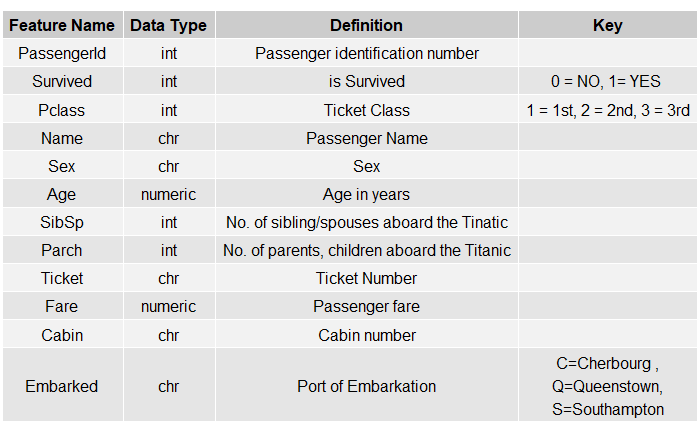

```r
type <- c("int","int","int","chr","chr","numeric","int","int","chr","numeric","chr","chr")
description <- c("Passenger identification number","is Survived","Ticket Class","Passenger Name","Sex","Age in years","No. of sibling/spouses aboard the Tinatic","No. of parents, children aboard the Titanic","Ticket Number","Passenger fare","Cabin number","Port of Embarkation")
Key <- c("","0 = NO, 1= YES ","1 = 1st, 2 = 2nd, 3 = 3rd","","","","","","","","","C=Cherbourg ,\nQ=Queenstown,\nS=Southampton")
meta_data <- matrix(c(colnames(dataset),type,description,Key),nrow= 12, ncol=4)
colnames(meta_data) <- c("Feature Name","Data Type","Definition","Key")
grid.newpage()
grid.table(meta_data)
```

tidy up the data

```r
#Remove descriptive cols and store as dataset_exclude_Des
dataset_exclude_Des <- select(dataset, -Name, -Ticket, -Cabin, -PassengerId)
#Add Na field to "" data
dataset_exclude_Des <- dataset_exclude_Des %>% mutate_all(na_if,"")
#Remove rows with NA and store as dataset_exclude_NA
dataset_cleaned <- na.omit(dataset_exclude_Des)
#refactor the string value into group
glimpse(dataset_cleaned)
```

```
Rows: 712
Columns: 8
$ Survived <int> 0, 1, 1, 1, 0, 0, 0, 1, 1, 1, 1, 0, 0, 0, 1, 0, 0, 0, 1, 1, 1, 0, 1, 0, 0, 0, 0, 0, 0, 0, 1, 0, 0, 1, 1, 0, 0, 0, 1, 1, 0, 1, 0, 1, 0, 0, 0~
$ Pclass   <int> 3, 1, 3, 1, 3, 1, 3, 3, 2, 3, 1, 3, 3, 3, 2, 3, 3, 2, 2, 3, 1, 3, 3, 1, 1, 2, 1, 1, 3, 3, 3, 3, 2, 2, 3, 3, 3, 3, 1, 2, 1, 2, 3, 2, 3, 3, 1~
$ Sex      <chr> "male", "female", "female", "female", "male", "male", "male", "female", "female", "female", "female", "male", "male", "female", "female", "~
$ Age      <dbl> 22.0, 38.0, 26.0, 35.0, 35.0, 54.0, 2.0, 27.0, 14.0, 4.0, 58.0, 20.0, 39.0, 14.0, 55.0, 2.0, 31.0, 35.0, 34.0, 15.0, 28.0, 8.0, 38.0, 19.0,~
$ SibSp    <int> 1, 1, 0, 1, 0, 0, 3, 0, 1, 1, 0, 0, 1, 0, 0, 4, 1, 0, 0, 0, 0, 3, 1, 3, 0, 0, 1, 1, 0, 2, 1, 1, 1, 1, 0, 1, 4, 0, 1, 1, 0, 0, 0, 1, 5, 0, 1~
$ Parch    <int> 0, 0, 0, 0, 0, 0, 1, 2, 0, 1, 0, 0, 5, 0, 0, 1, 0, 0, 0, 0, 0, 1, 5, 2, 0, 0, 0, 0, 0, 0, 0, 0, 0, 2, 0, 0, 1, 0, 0, 0, 1, 0, 0, 2, 2, 0, 0~
$ Fare     <dbl> 7.2500, 71.2833, 7.9250, 53.1000, 8.0500, 51.8625, 21.0750, 11.1333, 30.0708, 16.7000, 26.5500, 8.0500, 31.2750, 7.8542, 16.0000, 29.1250, ~
$ Embarked <chr> "S", "C", "S", "S", "S", "S", "S", "S", "C", "S", "S", "S", "S", "S", "S", "Q", "S", "S", "S", "Q", "S", "S", "S", "S", "C", "S", "C", "S",~
```

```r
write.table(dataset_cleaned, file = "../result/train_cleaned.csv", sep = ",", row.names = FALSE)
```

check data integrity

```r
summary(data_integrity(dataset_cleaned))
```

```
√ No num/cat with NA. No high card. No one-value var.
```

re-factor and produce summary table

```r
dataset_summary <- data.frame(dataset_cleaned)
dataset_summary$Sex =  as.factor(dataset_summary $Sex)
dataset_summary$Embarked =  as.factor(dataset_summary$Embarked)
dataset_summary$Survived = as.factor(dataset_summary$Survived)
dataset_summary$Pclass = as.factor(dataset_summary$Pclass)
dataset_summary$SibSp = as.factor(dataset_summary$SibSp)
dataset_summary$Parch = as.factor(dataset_summary$Parch)
summary(dataset_summary )
```

```
 Survived Pclass      Sex           Age        SibSp   Parch        Fare        Embarked
 0:424    1:184   female:259   Min.   : 0.42   0:469   0:519   Min.   :  0.00   C:130
 1:288    2:173   male  :453   1st Qu.:20.00   1:183   1:110   1st Qu.:  8.05   Q: 28
          3:355                Median :28.00   2: 25   2: 68   Median : 15.65   S:554
                               Mean   :29.64   3: 12   3:  5   Mean   : 34.57
                               3rd Qu.:38.00   4: 18   4:  4   3rd Qu.: 33.00
                               Max.   :80.00   5:  5   5:  5   Max.   :512.33
                                                       6:  1
```

reformat table & perform summary function to get Summary of Statistics

```r
summ_table <- tableby(~Survived + Pclass+ Sex + Age + SibSp + Parch + Fare + Embarked, data= dataset_summary )

summary(summ_table, text=FALSE)
```

|  | Overall (N=712) |
| --- | --- |
| **Survived** |  |
| 0 | 424 (59.6%) |
| 1 | 288 (40.4%) |
| **Pclass** |  |
| 1 | 184 (25.8%) |
| 2 | 173 (24.3%) |
| 3 | 355 (49.9%) |
| **Sex** |  |
| female | 259 (36.4%) |
| male | 453 (63.6%) |
| **Age** |  |
| Mean (SD) | 29.642 (14.493) |
| Range | 0.420 - 80.000 |
| **SibSp** |  |
| 0 | 469 (65.9%) |
| 1 | 183 (25.7%) |
| 2 | 25 (3.5%) |
| 3 | 12 (1.7%) |
| 4 | 18 (2.5%) |
| 5 | 5 (0.7%) |
| **Parch** |  |
| 0 | 519 (72.9%) |
| 1 | 110 (15.4%) |
| 2 | 68 (9.6%) |
| 3 | 5 (0.7%) |
| 4 | 4 (0.6%) |
| 5 | 5 (0.7%) |
| 6 | 1 (0.1%) |
| **Fare** |  |
| Mean (SD) | 34.567 (52.939) |
| Range | 0.000 - 512.329 |
| **Embarked** |  |
| C | 130 (18.3%) |
| Q | 28 (3.9%) |
| S | 554 (77.8%) |

```
NA
```

additional information for quantitative factors

```r
descriptive_summary <-describe(dataset_cleaned[,c("Age","Fare")])
write.table(descriptive_summary, file = "../result/descriptive_summary.csv", sep = ",", row.names = FALSE)
descriptive_summary
```

|  | vars | n | mean | sd | median | trimmed | mad | min | max | range | skew | kurtosis | se |
| --- | --- | --- | --- | --- | --- | --- | --- | --- | --- | --- | --- | --- | --- |
| Age | 1 | 712 | 29.64 | 14.49 | 28.00 | 29.22 | 12.97 | 0.42 | 80.00 | 79.58 | 0.39 | 0.17 | 0.54 |
| Fare | 2 | 712 | 34.57 | 52.94 | 15.65 | 23.00 | 12.02 | 0.00 | 512.33 | 512.33 | 4.65 | 30.69 | 1.98 |

Survival rate proportion

```r
##Survived
row <- nrow(dataset)
freqtable <- table(Survived = dataset_cleaned$Survived)
df <- as.data.frame.table(freqtable)
df$Proportion <- df$Freq/712
df$lab <- as.character(round(100 * df$Freq / sum(df$Freq),digit=2))
##df$lab <- paste(df$Freq,paste("(",df$lab,"%)",sep=""),sep=" ")
df$lab <- paste(paste(df$lab,"%",sep=""),sep=" ")
head(df)
```

|  | Survived | Freq | Proportion | lab |
| --- | --- | --- | --- | --- |
| 1 | 0 | 424 | 0.5955056 | 59.55% |
| 2 | 1 | 288 | 0.4044944 | 40.45% |

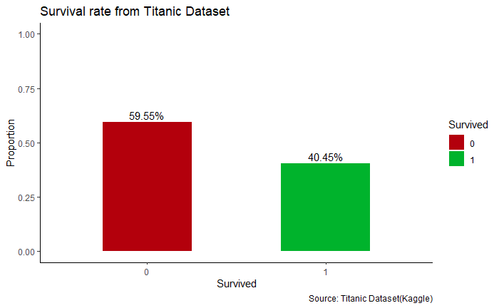

```r
theme_set(theme_classic())
g <- ggplot(df, aes( Survived, Proportion, fill= Survived))
g + geom_bar(stat="identity", width = 0.5)  +scale_fill_manual(values = c("#B3000C", "#00B32C"))+  geom_text(data=df,aes(x=Survived,y=Proportion,label=lab),vjust=-.3) +
      labs(title="Survival rate from Titanic Dataset",

           caption="Source: Titanic Dataset(Kaggle)") +
      theme(axis.text.x = element_text( vjust=0.6))+ylim(0,1)
```

Gender proportion

```r
freqtable <- table(Sex = dataset_cleaned$Sex)
df <- as.data.frame.table(freqtable)
df$Proportion <- df$Freq/712
df$lab <- as.character(round(100 * df$Freq / sum(df$Freq),digit=2))
df$lab <- paste(paste("",df$lab,"%",sep=""),sep=" ")
head(df)
```

|  | Sex | Freq | Proportion | lab |
| --- | --- | --- | --- | --- |
| 1 | female | 259 | 0.363764 | 36.38% |
| 2 | male | 453 | 0.636236 | 63.62% |

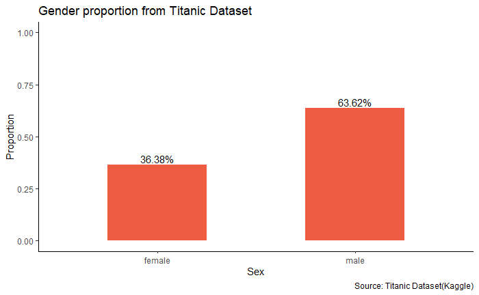

```r
theme_set(theme_classic())
g <- ggplot(df, aes( Sex, Proportion))
g + geom_bar(stat="identity", width = 0.5, fill="tomato2")  +  geom_text(data=df,aes(Sex,y=Proportion,label=lab),vjust=-.3) +
      labs(title="Gender proportion from Titanic Dataset",
           caption="Source: Titanic Dataset(Kaggle)") +
      theme(axis.text.x = element_text( vjust=0.6))+ylim(0,1)
```

Sibling & Spouse proportion

```r
freqtable <- table(SibSp = dataset_cleaned$SibSp)
df <- as.data.frame.table(freqtable)
df$Proportion <- df$Freq/712
df$lab <- as.character(round(100 * df$Freq / sum(df$Freq),digit=2))
df$lab <- paste(paste("",df$lab,"%",sep=""),sep=" ")
head(df)
```

|  | SibSp | Freq | Proportion | lab |
| --- | --- | --- | --- | --- |
| 1 | 0 | 469 | 0.658707865 | 65.87% |
| 2 | 1 | 183 | 0.257022472 | 25.7% |
| 3 | 2 | 25 | 0.035112360 | 3.51% |
| 4 | 3 | 12 | 0.016853933 | 1.69% |
| 5 | 4 | 18 | 0.025280899 | 2.53% |
| 6 | 5 | 5 | 0.007022472 | 0.7% |

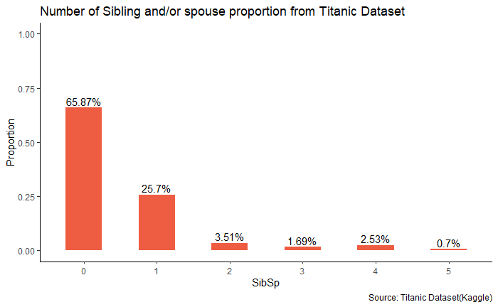

```r
theme_set(theme_classic())
g <- ggplot(df, aes( SibSp, Proportion))
g + geom_bar(stat="identity", width = 0.5, fill="tomato2")  +  geom_text(data=df,aes(SibSp,y=Proportion,label=lab),vjust=-.3) +
      labs(title="Number of Sibling and/or spouse proportion from Titanic Dataset",
           caption="Source: Titanic Dataset(Kaggle)") +
      theme(axis.text.x = element_text( vjust=0.6))+ylim(0,1)
```

Sibling & Parch proportion

```r
freqtable <- table(Parch = dataset_cleaned$Parch)
df <- as.data.frame.table(freqtable)
df$Proportion <- df$Freq/712
df$lab <- as.character(round(100 * df$Freq / sum(df$Freq),digit=2))
df$lab <- paste(paste("",df$lab,"%",sep=""),sep=" ")
head(df)
```

|  | Parch | Freq | Proportion | lab |
| --- | --- | --- | --- | --- |
| 1 | 0 | 519 | 0.728932584 | 72.89% |
| 2 | 1 | 110 | 0.154494382 | 15.45% |
| 3 | 2 | 68 | 0.095505618 | 9.55% |
| 4 | 3 | 5 | 0.007022472 | 0.7% |
| 5 | 4 | 4 | 0.005617978 | 0.56% |
| 6 | 5 | 5 | 0.007022472 | 0.7% |

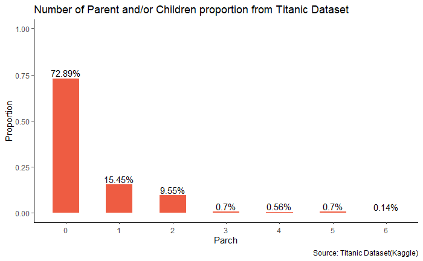

```r
theme_set(theme_classic())
g <- ggplot(df, aes( Parch, Proportion))
g + geom_bar(stat="identity", width = 0.5, fill="tomato2")  +  geom_text(data=df,aes(Parch,y=Proportion,label=lab),vjust=-.3) +
      labs(title="Number of Parent and/or Children proportion from Titanic Dataset",
           caption="Source: Titanic Dataset(Kaggle)") +
      theme(axis.text.x = element_text( vjust=0.6))+ylim(0,1)
```

Embarked proportion

```r
freqtable <- table(Embarked = dataset_cleaned$Embarked)
df <- as.data.frame.table(freqtable)
df$Proportion <- df$Freq/712
df$lab <- as.character(round(100 * df$Freq / sum(df$Freq),digit=2))
df$lab <- paste(paste("",df$lab,"%",sep=""),sep=" ")
head(df)
```

|  | Embarked | Freq | Proportion | lab |
| --- | --- | --- | --- | --- |
| 1 | C | 130 | 0.18258427 | 18.26% |
| 2 | Q | 28 | 0.03932584 | 3.93% |
| 3 | S | 554 | 0.77808989 | 77.81% |

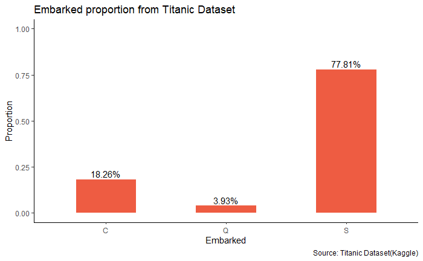

```r
theme_set(theme_classic())
g <- ggplot(df, aes( Embarked, Proportion))
g + geom_bar(stat="identity", width = 0.5, fill="tomato2")  +  geom_text(data=df,aes(Embarked,y=Proportion,label=lab),vjust=-.3) +
      labs(title="Embarked proportion from Titanic Dataset",
           caption="Source: Titanic Dataset(Kaggle)") +
      theme(axis.text.x = element_text( vjust=0.6))+ylim(0,1)
```

Tickey class proportion

```r
freqtable <- table(Class = dataset_cleaned$Pclass)
df <- as.data.frame.table(freqtable)
df$Proportion <- df$Freq/712
df$lab <- as.character(round(100 * df$Freq / sum(df$Freq),digit=2))
df$lab <- paste(paste("",df$lab,"%",sep=""),sep=" ")
head(df)
```

|  | Class | Freq | Proportion | lab |
| --- | --- | --- | --- | --- |
| 1 | 1 | 184 | 0.2584270 | 25.84% |
| 2 | 2 | 173 | 0.2429775 | 24.3% |
| 3 | 3 | 355 | 0.4985955 | 49.86% |

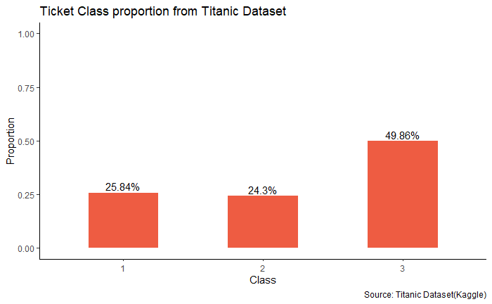

```r
theme_set(theme_classic())
g <- ggplot(df, aes( Class, Proportion))
g + geom_bar(stat="identity", width = 0.5, fill="tomato2")  +  geom_text(data=df,aes(Class,y=Proportion,label=lab),vjust=-.3) +
      labs(title="Ticket Class proportion from Titanic Dataset",
           caption="Source: Titanic Dataset(Kaggle)") +
      theme(axis.text.x = element_text( vjust=0.6))+ylim(0,1)
```

Age histrogram

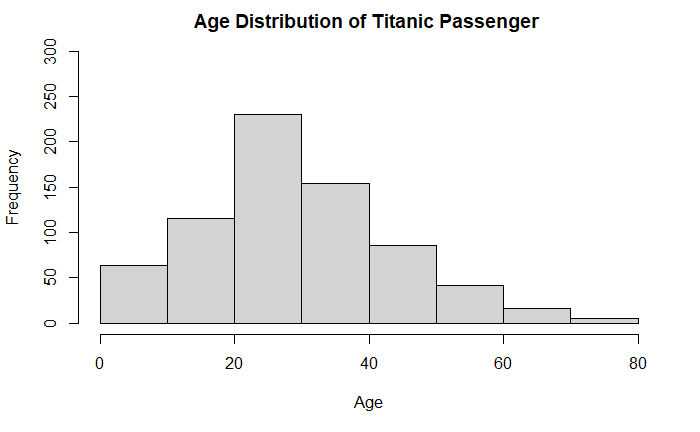

```r
hist(dataset_cleaned$Age,main= "Age Distribution of Titanic Passenger ", xlab = "Age", ylim = range(0,300))
```

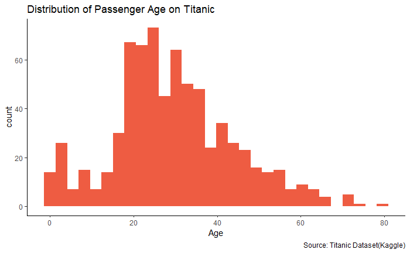

```r
p <- ggplot(dataset_cleaned, aes(x=Age)) + geom_histogram(fill="tomato2") +labs(title="Distribution of Passenger Age on Titanic",
           caption="Source: Titanic Dataset(Kaggle)")
p
```

Histogram of fare

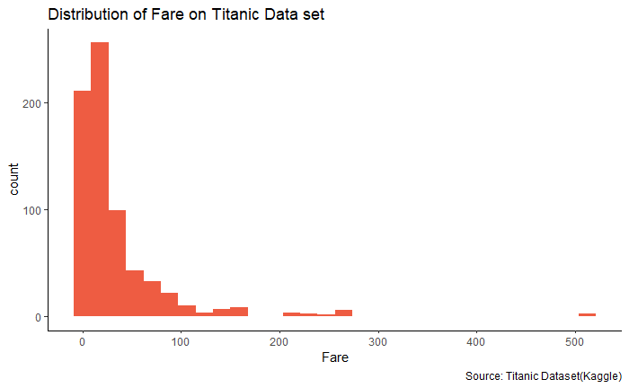

```r
p <- ggplot(dataset_cleaned, aes(x=Fare)) + geom_histogram(fill="tomato2") + labs(title="Distribution of Fare on Titanic Data set",
           caption="Source: Titanic Dataset(Kaggle)")
p
```

Survival proportion of each ticket class

```r
##Survived
freqtable <- table(Class=dataset_cleaned$Pclass,Survived=dataset_cleaned$Survived)
df <- as.data.frame.table(freqtable)
df$lab <- as.character(round(100 * df$Freq / sum(df$Freq),digit=2))
#get sum of each class
df$sum_class <- ave(df$Freq,df$Class,FUN=sum)

df$lab_class <- as.character(round(100 * df$Freq /df$sum_class,digit=2))
df$Proportion <- df$Freq /df$sum_class
df$lab <- paste(paste("",df$lab,"%",sep=""),sep=" ")
df$lab_class <- paste(paste("",df$lab_class,"%",sep=""),sep=" ")

head(df)
```

|  | Class | Survived | Freq | lab | sum_class | lab_class | Proportion |
| --- | --- | --- | --- | --- | --- | --- | --- |
| 1 | 1 | 0 | 64 | 8.99% | 184 | 34.78% | 0.3478261 |
| 2 | 2 | 0 | 90 | 12.64% | 173 | 52.02% | 0.5202312 |
| 3 | 3 | 0 | 270 | 37.92% | 355 | 76.06% | 0.7605634 |
| 4 | 1 | 1 | 120 | 16.85% | 184 | 65.22% | 0.6521739 |
| 5 | 2 | 1 | 83 | 11.66% | 173 | 47.98% | 0.4797688 |
| 6 | 3 | 1 | 85 | 11.94% | 355 | 23.94% | 0.2394366 |

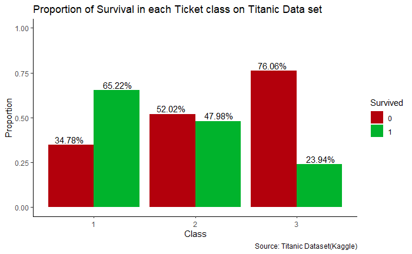

```r
x_label <- c("First Class", "Second Class", "Third Class")
type <- c("Death", "Alive")
theme_set(theme_classic())
g <- ggplot(df, aes( Class, Proportion, fill=Survived))
g + geom_bar(stat="identity", position=position_dodge())   +scale_fill_manual(values = c( "#B3000C","#00B32C")) +
  geom_text(data=df,aes(x=Class,y=Proportion,label=lab_class),vjust=-.3,position=position_dodge(width= .95))+
      labs(title="Proportion of Survival in each Ticket class on Titanic Data set",
           caption="Source: Titanic Dataset(Kaggle)") +
      theme(axis.text.x = element_text( vjust=0.6))+ylim(0,1)
```

boxplot of age of both survivor & non-survivior

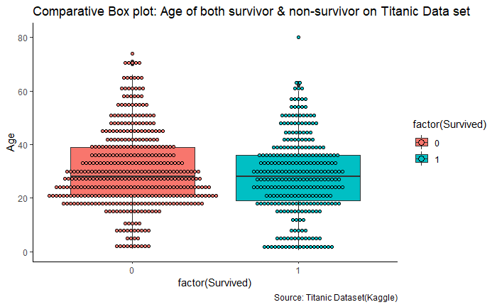

```r
p <- ggplot(dataset_cleaned, aes(y=Age, x= factor(Survived),fill=factor(Survived)))+ scale_y_continuous("Age") +geom_boxplot()+ geom_dotplot(binaxis='y', stackdir='center', dotsize=0.5)+ labs(title="Comparative Box plot: Age of both survivor & non-survivor on Titanic Data set",
           caption="Source: Titanic Dataset(Kaggle)")
p
```

distribution of age of both survivor & non-survival

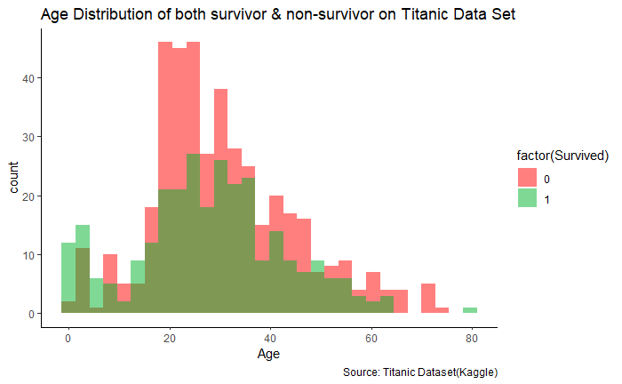

```r
p <- ggplot(dataset_cleaned, aes(x=Age,fill=factor(Survived))) + geom_histogram(position="identity", alpha= 0.5) +scale_fill_manual(values=c("#FF0000", "#00B32C")) +labs(title="Age Distribution of both survivor & non-survivor on Titanic Data Set",
           caption="Source: Titanic Dataset(Kaggle)")
p
```

Surivial rate in each age range

```r
df <- dataset_cleaned[,c("Survived","Age")]
df_age_range <- df %>% mutate(Age_range = case_when(Age > 60   ~ '60 +',Age > 50  & Age <= 60 ~ '51 - 60',Age > 40  & Age <= 50 ~ '41 - 50',Age > 30  & Age <= 40 ~ '31 - 40',Age > 20  & Age <= 30 ~ '21 - 30',Age > 10  & Age <= 20 ~ '11 - 20',Age > 0 & Age <=10 ~ '0 - 10' ))
df_age_range
```

|  | Survived | Age | Age_range |
| --- | --- | --- | --- |
| 1 | 0 | 22.00 | 21 - 30 |
| 2 | 1 | 38.00 | 31 - 40 |
| 3 | 1 | 26.00 | 21 - 30 |
| 4 | 1 | 35.00 | 31 - 40 |
| 5 | 0 | 35.00 | 31 - 40 |
| 7 | 0 | 54.00 | 51 - 60 |
| 8 | 0 | 2.00 | 0 - 10 |
| 9 | 1 | 27.00 | 21 - 30 |
| 10 | 1 | 14.00 | 11 - 20 |
| 11 | 1 | 4.00 | 0 - 10 |

[output cut: 702 more lines]

```r
#initial
x= df_age_range$Age_range
y= df_age_range$Survived

freqtable <- table(x,Survived = df_age_range$Survived)
df <- as.data.frame.table(freqtable)
df$lab <- as.character(round(100 * df$Freq / sum(df$Freq),digit=2))
head(df)
```

|  | x | Survived | Freq | lab |
| --- | --- | --- | --- | --- |
| 1 | 0 - 10 | 0 | 26 | 3.65 |
| 2 | 11 - 20 | 0 | 71 | 9.97 |
| 3 | 21 - 30 | 0 | 146 | 20.51 |
| 4 | 31 - 40 | 0 | 86 | 12.08 |
| 5 | 41 - 50 | 0 | 53 | 7.44 |
| 6 | 51 - 60 | 0 | 25 | 3.51 |

```r
#get sum of each class
df$sum_class <- ave(df$Freq,df$x,FUN=sum)

df$lab_cate <- as.character(round(100 * df$Freq /df$sum_class,digit=2))
df$Proportion <- df$Freq /df$sum_class
df$lab <- paste(paste("",df$lab,"%",sep=""),sep=" ")
df$lab_cate <- paste(paste("    ",df$lab_cate,"%",sep=""),sep=" ")

head(df)
```

|  | x | Survived | Freq | lab | sum_class | lab_cate | Proportion |
| --- | --- | --- | --- | --- | --- | --- | --- |
| 1 | 0 - 10 | 0 | 26 | 3.65% | 64 | 40.62% | 0.4062500 |
| 2 | 11 - 20 | 0 | 71 | 9.97% | 115 | 61.74% | 0.6173913 |
| 3 | 21 - 30 | 0 | 146 | 20.51% | 230 | 63.48% | 0.6347826 |
| 4 | 31 - 40 | 0 | 86 | 12.08% | 154 | 55.84% | 0.5584416 |
| 5 | 41 - 50 | 0 | 53 | 7.44% | 86 | 61.63% | 0.6162791 |
| 6 | 51 - 60 | 0 | 25 | 3.51% | 42 | 59.52% | 0.5952381 |

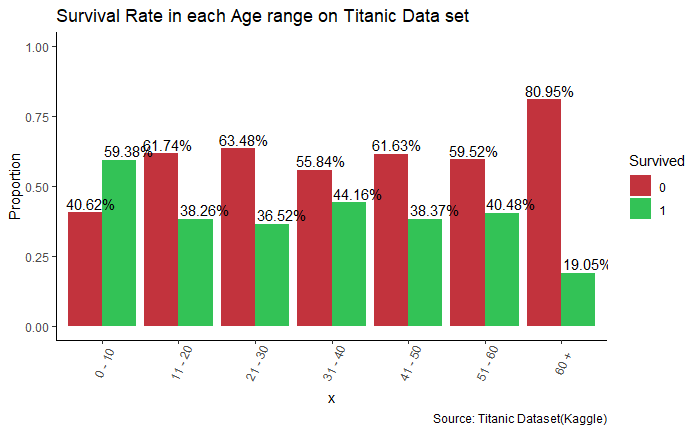

```r
x_label <- c("First Class", "Second Class", "Third Class")
type <- c("Death", "Alive")
theme_set(theme_classic())
g <- ggplot(df, aes( x, Proportion, fill=Survived))
g + geom_bar(stat="identity", position=position_dodge(),width=0.9,alpha=0.8)   +scale_fill_manual(values = c( "#B3000C","#00B32C")) +
  geom_text(data=df,aes(x,y=Proportion,label=lab_cate),vjust=-.3,position=position_dodge(width=0.99), )+
      labs(title="Survival Rate in each Age range on Titanic Data set",
           caption="Source: Titanic Dataset(Kaggle)") +
      theme(axis.text.x = element_text(angle=65, vjust=0.6))+ylim(0,1)
```

Proportion of survival in each parent and/or child value

```r
#initial axis
x= dataset_cleaned$Parch
freqtable <- table(Parch=dataset_cleaned$Parch,Survived=dataset_cleaned$Survived)
df <- as.data.frame.table(freqtable)
df$lab <- as.character(round(100 * df$Freq / sum(df$Freq),digit=2))
#get sum of each class
df$sum_class <- ave(df$Freq,df$Parch,FUN=sum)

df$lab_Parch <- as.character(round(100 * df$Freq /df$sum_class,digit=2))
df$Proportion <- df$Freq /df$sum_class
df$lab <- paste(paste("",df$lab,"%",sep=""),sep=" ")
df$lab_Parch <- paste(paste("   ",df$lab_Parch,"%",sep=""),sep=" ")

head(df)
```

|  | Parch | Survived | Freq | lab | sum_class | lab_Parch | Proportion |
| --- | --- | --- | --- | --- | --- | --- | --- |
| 1 | 0 | 0 | 335 | 47.05% | 519 | 64.55% | 0.6454721 |
| 2 | 1 | 0 | 49 | 6.88% | 110 | 44.55% | 0.4454545 |
| 3 | 2 | 0 | 29 | 4.07% | 68 | 42.65% | 0.4264706 |
| 4 | 3 | 0 | 2 | 0.28% | 5 | 40% | 0.4000000 |
| 5 | 4 | 0 | 4 | 0.56% | 4 | 100% | 1.0000000 |
| 6 | 5 | 0 | 4 | 0.56% | 5 | 80% | 0.8000000 |

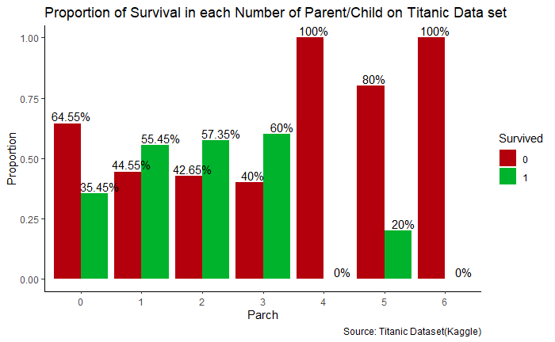

```r
x_label <- c("First Class", "Second Class", "Third Class")
type <- c("Death", "Alive")
theme_set(theme_classic())
g <- ggplot(df, aes( Parch, Proportion, fill=Survived))
g + geom_bar(stat="identity", position=position_dodge())   +scale_fill_manual(values = c( "#B3000C","#00B32C")) +
  geom_text(data=df,aes(x=Parch,y=Proportion,label=lab_Parch),vjust=-.3,position=position_dodge(width= .95))+
      labs(title="Proportion of Survival in each Number of Parent/Child on Titanic Data set",
           caption="Source: Titanic Dataset(Kaggle)") +
      theme(axis.text.x = element_text( vjust=0.6))+ylim(0,1)
```

Proportion of survival in each Sibling and/or Spouse value

```r
#initial axis
x= dataset_cleaned$SibSp
freqtable <- table(SibSp=dataset_cleaned$SibSp,Survived=dataset_cleaned$Survived)
df <- as.data.frame.table(freqtable)
df$lab <- as.character(round(100 * df$Freq / sum(df$Freq),digit=2))
head(df)
```

|  | SibSp | Survived | Freq | lab |
| --- | --- | --- | --- | --- |
| 1 | 0 | 0 | 296 | 41.57 |
| 2 | 1 | 0 | 86 | 12.08 |
| 3 | 2 | 0 | 14 | 1.97 |
| 4 | 3 | 0 | 8 | 1.12 |
| 5 | 4 | 0 | 15 | 2.11 |
| 6 | 5 | 0 | 5 | 0.7 |

```r
#get sum of each class
df$sum_class <- ave(df$Freq,df$SibSp,FUN=sum)

df$lab_Parch <- as.character(round(100 * df$Freq /df$sum_class,digit=2))
df$Proportion <- df$Freq /df$sum_class
df$lab <- paste(paste("",df$lab,"%",sep=""),sep=" ")
df$lab_Parch <- paste(paste("  ",df$lab_Parch,"%",sep=""),sep=" ")

head(df)
```

|  | SibSp | Survived | Freq | lab | sum_class | lab_Parch | Proportion |
| --- | --- | --- | --- | --- | --- | --- | --- |
| 1 | 0 | 0 | 296 | 41.57% | 469 | 63.11% | 0.6311301 |
| 2 | 1 | 0 | 86 | 12.08% | 183 | 46.99% | 0.4699454 |
| 3 | 2 | 0 | 14 | 1.97% | 25 | 56% | 0.5600000 |
| 4 | 3 | 0 | 8 | 1.12% | 12 | 66.67% | 0.6666667 |
| 5 | 4 | 0 | 15 | 2.11% | 18 | 83.33% | 0.8333333 |
| 6 | 5 | 0 | 5 | 0.7% | 5 | 100% | 1.0000000 |

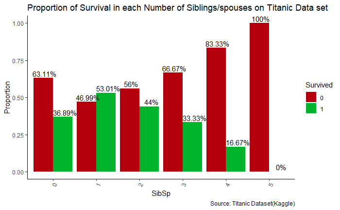

```r
x_label <- c("First Class", "Second Class", "Third Class")
type <- c("Death", "Alive")
theme_set(theme_classic())
g <- ggplot(df, aes( SibSp, Proportion, fill=Survived))
g + geom_bar(stat="identity", position=position_dodge())   +scale_fill_manual(values = c( "#B3000C","#00B32C")) +
  geom_text(data=df,aes(x=SibSp,y=Proportion,label=lab_Parch),vjust=-.3,position=position_dodge(width= .95))+
      labs(title="Proportion of Survival in each Number of Siblings/spouses on Titanic Data set",
           caption="Source: Titanic Dataset(Kaggle)") +
      theme(axis.text.x = element_text(angle=65, vjust=0.6))+ylim(0,1)
```

Proportion of survival in each Embarked port

```r
x= dataset_cleaned$Embarked
freqtable <- table(x,Survived=dataset_cleaned$Survived)
df <- as.data.frame.table(freqtable)
df$lab <- as.character(round(100 * df$Freq / sum(df$Freq),digit=2))
head(df)
```

|  | x | Survived | Freq | lab |
| --- | --- | --- | --- | --- |
| 1 | C | 0 | 51 | 7.16 |
| 2 | Q | 0 | 20 | 2.81 |
| 3 | S | 0 | 353 | 49.58 |
| 4 | C | 1 | 79 | 11.1 |
| 5 | Q | 1 | 8 | 1.12 |
| 6 | S | 1 | 201 | 28.23 |

```r
#get sum of each class
df$sum_class <- ave(df$Freq,df$x,FUN=sum)

df$lab_cate <- as.character(round(100 * df$Freq /df$sum_class,digit=2))
df$Proportion <- df$Freq /df$sum_class
df$lab <- paste(paste("",df$lab,"%",sep=""),sep=" ")
df$lab_cate <- paste(paste("",df$lab_cate,"%",sep=""),sep=" ")

head(df)
```

|  | x | Survived | Freq | lab | sum_class | lab_cate | Proportion |
| --- | --- | --- | --- | --- | --- | --- | --- |
| 1 | C | 0 | 51 | 7.16% | 130 | 39.23% | 0.3923077 |
| 2 | Q | 0 | 20 | 2.81% | 28 | 71.43% | 0.7142857 |
| 3 | S | 0 | 353 | 49.58% | 554 | 63.72% | 0.6371841 |
| 4 | C | 1 | 79 | 11.1% | 130 | 60.77% | 0.6076923 |
| 5 | Q | 1 | 8 | 1.12% | 28 | 28.57% | 0.2857143 |
| 6 | S | 1 | 201 | 28.23% | 554 | 36.28% | 0.3628159 |

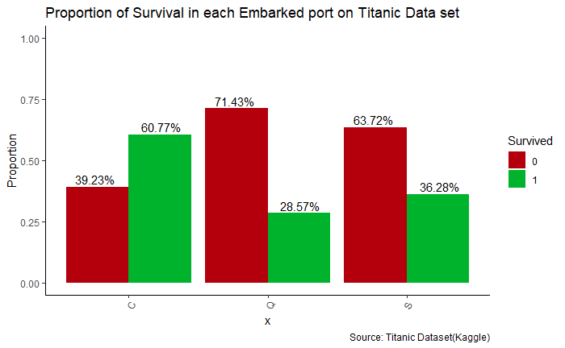

```r
x_label <- c("First Class", "Second Class", "Third Class")
type <- c("Death", "Alive")
theme_set(theme_classic())
g <- ggplot(df, aes( x, Proportion, fill=Survived))
g + geom_bar(stat="identity", position=position_dodge())   +scale_fill_manual(values = c( "#B3000C","#00B32C")) +
  geom_text(data=df,aes(x,y=Proportion,label=lab_cate),vjust=-.3,position=position_dodge(width= .95))+
      labs(title="Proportion of Survival in each Embarked port on Titanic Data set",

           caption="Source: Titanic Dataset(Kaggle)") +
      theme(axis.text.x = element_text(angle=65, vjust=0.6))+ylim(0,1)
```

boxplot of fare of both survivor & non-survivior

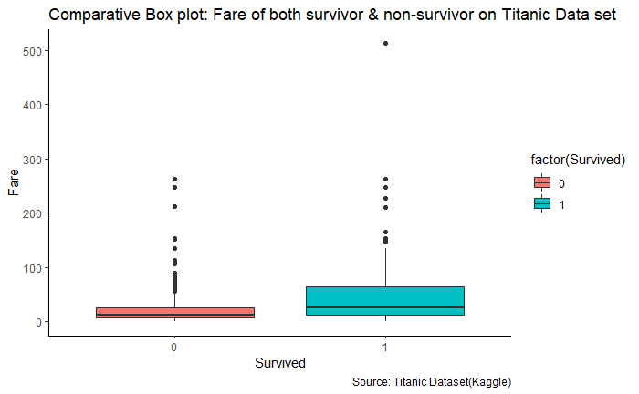

```r
p <- ggplot(dataset_cleaned, aes(y=Fare, x= factor(Survived),fill=factor(Survived)))+ scale_y_continuous("Fare") +geom_boxplot() +xlab("Survived") + labs(title="Comparative Box plot: Fare of both survivor & non-survivor on Titanic Data set",
           caption="Source: Titanic Dataset(Kaggle)")
p
```

Fair Distribution of both survivor & non-survivor

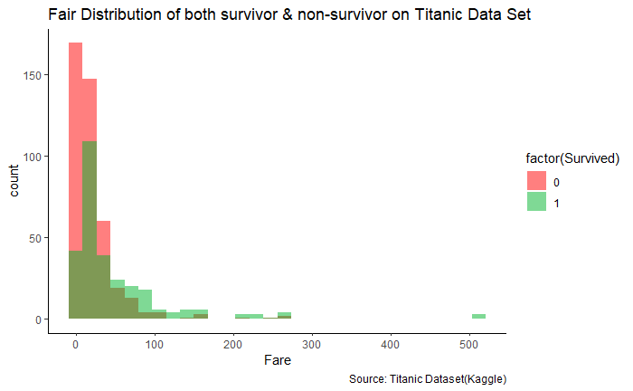

```r
p <- ggplot(dataset_cleaned, aes(x=Fare,fill=factor(Survived))) + geom_histogram(position="identity", alpha= 0.5) +scale_fill_manual(values=c("#FF0000", "#00B32C")) +  labs(title="Fair Distribution of both survivor & non-survivor on Titanic Data Set",
           caption="Source: Titanic Dataset(Kaggle)")
p
```

survivor proportion in each fare range

```r
df <- dataset_cleaned[,c("Survived","Fare")]
df_fare_range <- df %>% mutate(Fare_range = case_when(Fare > 200   ~ '200+',Fare > 100  & Fare <= 200 ~ '101 - 200',Fare >= 0  & Fare <= 100 ~ '0 - 100'))
df_fare_range
```

|  | Survived | Fare | Fare_range |
| --- | --- | --- | --- |
| 1 | 0 | 7.2500 | 0 - 100 |
| 2 | 1 | 71.2833 | 0 - 100 |
| 3 | 1 | 7.9250 | 0 - 100 |
| 4 | 1 | 53.1000 | 0 - 100 |
| 5 | 0 | 8.0500 | 0 - 100 |
| 7 | 0 | 51.8625 | 0 - 100 |
| 8 | 0 | 21.0750 | 0 - 100 |
| 9 | 1 | 11.1333 | 0 - 100 |
| 10 | 1 | 30.0708 | 0 - 100 |
| 11 | 1 | 16.7000 | 0 - 100 |

[output cut: 702 more lines]

```r
#initial
x= df_fare_range$Fare_range
y= df_fare_range$Survived

freqtable <- table(x,Survived = df_fare_range$Survived)
df <- as.data.frame.table(freqtable)
df$lab <- as.character(round(100 * df$Freq / sum(df$Freq),digit=2))
head(df)
```

|  | x | Survived | Freq | lab |
| --- | --- | --- | --- | --- |
| 1 | 0 - 100 | 0 | 412 | 57.87 |
| 2 | 101 - 200 | 0 | 8 | 1.12 |
| 3 | 200+ | 0 | 4 | 0.56 |
| 4 | 0 - 100 | 1 | 252 | 35.39 |
| 5 | 101 - 200 | 1 | 22 | 3.09 |
| 6 | 200+ | 1 | 14 | 1.97 |

```r
#get sum of each class
df$sum_class <- ave(df$Freq,df$x,FUN=sum)

df$lab_cate <- as.character(round(100 * df$Freq /df$sum_class,digit=2))
df$Proportion <- df$Freq /df$sum_class
df$lab <- paste(paste("",df$lab,"%",sep=""),sep=" ")
df$lab_cate <- paste(paste("",df$lab_cate,"%",sep=""),sep=" ")

head(df)
```

|  | x | Survived | Freq | lab | sum_class | lab_cate | Proportion |
| --- | --- | --- | --- | --- | --- | --- | --- |
| 1 | 0 - 100 | 0 | 412 | 57.87% | 664 | 62.05% | 0.6204819 |
| 2 | 101 - 200 | 0 | 8 | 1.12% | 30 | 26.67% | 0.2666667 |
| 3 | 200+ | 0 | 4 | 0.56% | 18 | 22.22% | 0.2222222 |
| 4 | 0 - 100 | 1 | 252 | 35.39% | 664 | 37.95% | 0.3795181 |
| 5 | 101 - 200 | 1 | 22 | 3.09% | 30 | 73.33% | 0.7333333 |
| 6 | 200+ | 1 | 14 | 1.97% | 18 | 77.78% | 0.7777778 |

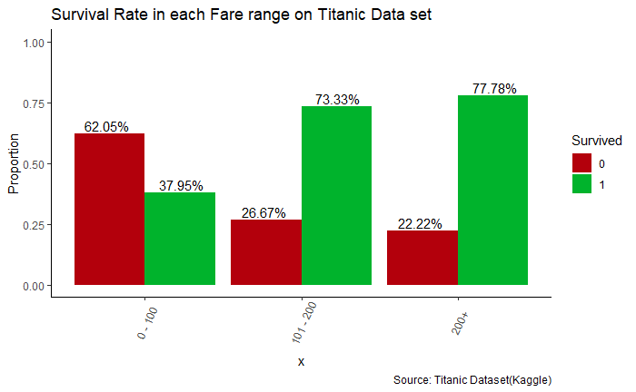

```r
x_label <- c("First Class", "Second Class", "Third Class")
type <- c("Death", "Alive")
theme_set(theme_classic())
g <- ggplot(df, aes( x, Proportion, fill=Survived))
g + geom_bar(stat="identity", position=position_dodge())   +scale_fill_manual(values = c( "#B3000C","#00B32C")) +
  geom_text(data=df,aes(x,y=Proportion,label=lab_cate),vjust=-.3,position=position_dodge(width= .95))+
      labs(title="Survival Rate in each Fare range on Titanic Data set",
           caption="Source: Titanic Dataset(Kaggle)") +
      theme(axis.text.x = element_text(angle=65, vjust=0.6))+ylim(0,1)
```

```r
NA
```

survivor proportion in each gender

```r
x= dataset_cleaned$Sex
freqtable <- table(x,Survived=dataset_cleaned$Survived)
df <- as.data.frame.table(freqtable)
df$lab <- as.character(round(100 * df$Freq / sum(df$Freq),digit=2))
head(df)
```

|  | x | Survived | Freq | lab |
| --- | --- | --- | --- | --- |
| 1 | female | 0 | 64 | 8.99 |
| 2 | male | 0 | 360 | 50.56 |
| 3 | female | 1 | 195 | 27.39 |
| 4 | male | 1 | 93 | 13.06 |

```r
#get sum of each class
df$sum_class <- ave(df$Freq,df$x,FUN=sum)

df$lab_cate <- as.character(round(100 * df$Freq /df$sum_class,digit=2))
df$Proportion <- df$Freq /df$sum_class
df$lab <- paste(paste("",df$lab,"%",sep=""),sep=" ")
df$lab_cate <- paste(paste("",df$lab_cate,"%",sep=""),sep=" ")

head(df)
```

|  | x | Survived | Freq | lab | sum_class | lab_cate | Proportion |
| --- | --- | --- | --- | --- | --- | --- | --- |
| 1 | female | 0 | 64 | 8.99% | 259 | 24.71% | 0.2471042 |
| 2 | male | 0 | 360 | 50.56% | 453 | 79.47% | 0.7947020 |
| 3 | female | 1 | 195 | 27.39% | 259 | 75.29% | 0.7528958 |
| 4 | male | 1 | 93 | 13.06% | 453 | 20.53% | 0.2052980 |

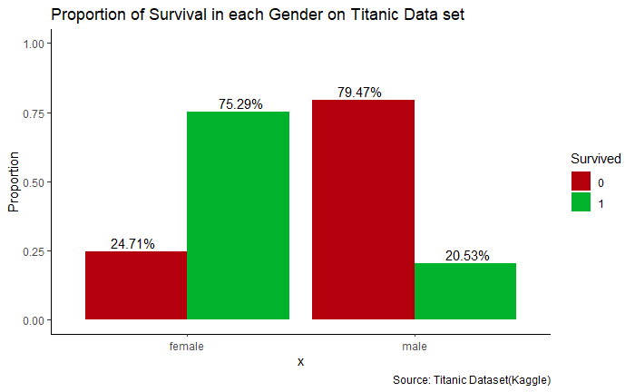

```r
x_label <- c("First Class", "Second Class", "Third Class")
type <- c("Death", "Alive")
theme_set(theme_classic())
g <- ggplot(df, aes( x, Proportion, fill=Survived))
g + geom_bar(stat="identity", position=position_dodge())   +scale_fill_manual(values = c( "#B3000C","#00B32C")) +
  geom_text(data=df,aes(x,y=Proportion,label=lab_cate),vjust=-.3,position=position_dodge(width= .95))+
      labs(title="Proportion of Survival in each Gender on Titanic Data set",
           caption="Source: Titanic Dataset(Kaggle)") +
      theme(axis.text.x = element_text( vjust=0.6))+ylim(0,1)
```